# Ejemplos introductorios a la estadística

Salvador Díaz Maldonado

2025-01-11

https://bookdown.org/jboscomendoza/r-principiantes4/  
https://www.uv.es/vcoll/curso_r.html

# ESTADÍSTICA DESCRIPTIVA

## Análisis gráfico de datos

Una etapa preliminar de análisis gráfico de los datos a procesar en un estudio estadístico es muy importante. Este análisis previo proporciona información crucial.

Para describir la importancia este punto se presenta el *cuarteto de Anscombe*, que comprende cuatro conjuntos de datos que tienen estadísticas descriptivas simples muy similares, pero que tienen distribuciones muy diferentes y resultan muy diferentes cuando se grafican.

https://medium.com/@zumaia/anscombes-quartet-in-r-535a50ee3bd9

| x1 | x2 | x3 | x4 | y1 | y2 | y3 | y4 |
| --- | --- | --- | --- | --- | --- | --- | --- |
| 10 | 10 | 10 | 8 | 8.04 | 9.14 | 7.46 | 6.58 |
| 8 | 8 | 8 | 8 | 6.95 | 8.14 | 6.77 | 5.76 |
| 13 | 13 | 13 | 8 | 7.58 | 8.74 | 12.74 | 7.71 |
| 9 | 9 | 9 | 8 | 8.81 | 8.77 | 7.11 | 8.84 |
| 11 | 11 | 11 | 8 | 8.33 | 9.26 | 7.81 | 8.47 |
| 14 | 14 | 14 | 8 | 9.96 | 8.10 | 8.84 | 7.04 |
| 6 | 6 | 6 | 8 | 7.24 | 6.13 | 6.08 | 5.25 |
| 4 | 4 | 4 | 19 | 4.26 | 3.10 | 5.39 | 12.50 |
| 12 | 12 | 12 | 8 | 10.84 | 9.13 | 8.15 | 5.56 |
| 7 | 7 | 7 | 8 | 4.82 | 7.26 | 6.42 | 7.91 |

[output cut: 1 more lines]

Medias de *x*´$_s$ y *y*´$_s$:

```
## [1] 9.000000 9.000000 9.000000 9.000000 7.500909 7.500909 7.500000 7.500909
```

Varianzas de *x*´$_s$ y *y*´$_s$:

```
## [1] 11.000000 11.000000 11.000000 11.000000  4.127269  4.127629  4.122620
## [8]  4.123249
```

Correlaciones (*x*´$_s$, *y*´$_s$):

```
## [1] 0.8164205 0.8162365 0.8162867 0.8165214
```

Como se aprecia, las medias, varianzas y los coeficientes de correlación de los cuatro conjuntos de datos son muy similares. Con estos resultados se podría suponer que dichos conjuntos de datos poseen una relación lineal robusta entre las variables dependientes *x*´$_s$ e independientes *y*´$_s$.

A continuación se calculan y grafican las regresiones lineales de los cuatro conjuntos de datos:

```
##
## Call:
## lm(formula = y1 ~ x1, data = anscombe)
##
## Coefficients:
## (Intercept)           x1
##      3.0001       0.5001
```

```
##
## Call:
## lm(formula = y2 ~ x2, data = anscombe)
##
## Coefficients:
## (Intercept)           x2
##       3.001        0.500
```

```
##
## Call:
## lm(formula = y3 ~ x3, data = anscombe)
##
## Coefficients:
## (Intercept)           x3
##      3.0025       0.4997
```

```
##
## Call:
## lm(formula = y4 ~ x4, data = anscombe)
##
## Coefficients:
## (Intercept)           x4
##      3.0017       0.4999
```

Las pendientes y las intersecciones de las regresiones lineales simples de los cuatro conjuntos de datos, son muy similares.

Por otro lado, las gráficas resultantes son:

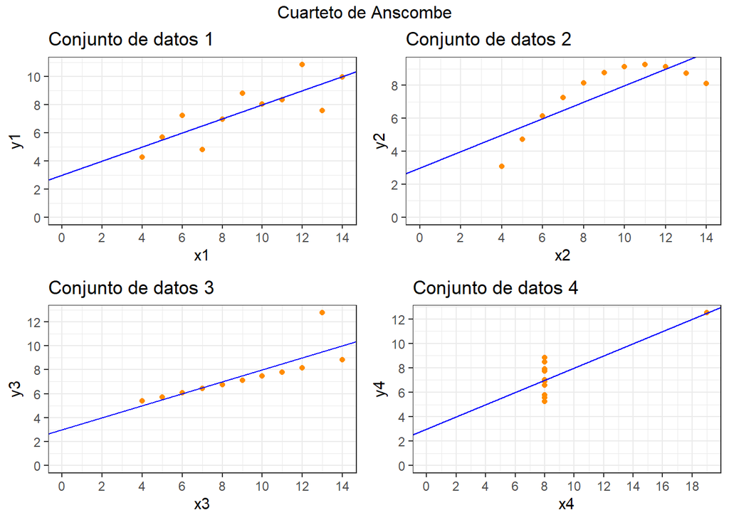

Las gráficas muestran un comportamiento muy diferente de los cuatro conjuntos de datos.

Lo anterior revela la importancia de las gráficas preliminares en un análisis estadístico, lo cual puede confirmar, o no, las suposiciones preliminares, además de ofrecer una oportunidad de explicar mejor el fenómeno bajo estudio.

### Ejemplo 1

https://rpubs.com/oscarrdiaz/871798

Se procesan las aportaciones deducidas mensuales en la presa Mocúzari, para los ciclos agrícolas 1955-56 a 2023-24, específicamente para los meses de febrero y agosto (en $hm^{3}$) -Fuente: CONAGUA-.

*Aportaciones deducidas mensuales 1955-56 a 2023-24*. Compare las aportaciones de dos meses (febrero vs agosto) utilizando un gráfico Q-Q. Además, trace otro tipo de gráfico. Describa las similitudes y diferencias en la aportación deducida entre estos dos meses. ¿Qué características son evidentes en cada gráfico?

**Aportación deducida 1955-56 a 2023-24, $hm^{3}$**

| CICLO | OCT | NOV | DIC | ENE | FEB | MAR | ABR | MAY | JUN | JUL | AGO | SEP | ANUAL |
| --- | --- | --- | --- | --- | --- | --- | --- | --- | --- | --- | --- | --- | --- |
| 55-56 | 146.6193 | 2.5975 | 7.3022 | 12.0575 | 4.9996 | 12.1461 | 1.1202 | 7.9474 | 48.8055 | 146.7903 | 149.7155 | 51.8092 | 591.9103 |
| 56-57 | 18.8920 | 8.0186 | 9.8465 | 83.0117 | 36.1804 | 12.7724 | 8.1366 | 4.0916 | 0.0000 | 117.0348 | 178.4610 | 67.4034 | 543.7656 |
| 57-58 | 160.8561 | 13.2421 | 16.9879 | 17.0894 | 35.8037 | 148.8544 | 15.1282 | 21.7735 | 38.3350 | 127.2440 | 234.7281 | 156.5968 | 986.6395 |
| 58-59 | 61.2241 | 0.0689 | 7.4148 | 9.5127 | 53.1516 | 13.7701 | 5.4958 | 6.7819 | 18.6468 | 198.4467 | 532.2945 | 79.8120 | 986.6200 |
| 59-60 | 203.9168 | 29.2766 | 90.8274 | 613.2360 | 37.5227 | 24.6670 | 10.6946 | 9.2868 | 1.9242 | 124.0308 | 235.7044 | 162.6673 | 1543.7545 |
| 60-61 | 33.4251 | 15.3629 | 35.5229 | 259.7274 | 45.5163 | 20.7042 | 13.0391 | 10.3367 | 42.5470 | 186.7662 | 270.8927 | 174.6180 | 1108.4584 |
| 61-62 | 125.0372 | 105.6923 | 31.2176 | 100.9235 | 29.1457 | 16.4935 | 16.8642 | 18.4362 | 18.4935 | 120.2362 | 73.7759 | 190.8471 | 847.1630 |
| 62-63 | 37.4641 | 20.5525 | 26.4183 | 18.9014 | 22.6966 | 22.0185 | 10.0876 | 6.6182 | 1.3633 | 179.7925 | 281.4309 | 94.4809 | 721.8249 |
| 63-64 | 29.8585 | 8.8605 | 218.4432 | 20.4664 | 15.1910 | 22.5935 | 15.8472 | 10.7741 | 12.8013 | 152.0948 | 360.4122 | 345.6965 | 1213.0392 |
| 64-65 | 24.6217 | 13.4694 | 21.9473 | 17.1422 | 78.1385 | 29.0037 | 12.6635 | 8.5099 | 6.2201 | 81.2014 | 143.9383 | 212.4073 | 649.2633 |

[output cut: 59 more lines]

**Aportación deducida de febrero, $hm^{3}$**

```
##  [1]   4.9996  36.1804  35.8037  53.1516  37.5227  45.5163  29.1457  22.6966
##  [9]  15.1910  78.1385  69.0743   0.9429 128.2198  37.1329   8.0818   4.4331
## [17]  20.0631 162.4026  10.8389  25.7026  14.5098  10.1307  17.5897 173.7450
## [25]   1.1885  31.4139   4.1837 200.9110  35.2725 117.1715  19.3773  19.2798
## [33]   0.0000 102.8106  75.3250  53.7235 210.1840 135.6565  22.5950 156.1625
## [41]  14.3977  16.6657  33.5566   0.0000   0.0000  64.4261  20.4724  44.8449
## [49]  15.2344 343.3725  18.9282  33.0173  26.8829  20.9574  88.0247  18.2080
## [57]   7.9699  19.6280  13.3798  50.4448  11.7918  15.8442   0.0000  47.5998
## [65]  29.8819   0.0000   0.0000  10.9550   0.7413
```

**Aportación deducida de agosto, $hm^{3}$**

```
##  [1] 149.7155 178.4610 234.7281 532.2945 235.7044 270.8927  73.7759 281.4309
##  [9] 360.4122 143.9383 640.0781 223.4347 289.7818 107.7970 295.9703 389.3848
## [17] 208.8496 386.3189 144.2277 251.2275 110.2226 337.6163 256.6089 146.9054
## [25] 393.2518 255.8442 142.0335 309.7554 486.8841 379.4506 291.4198 304.1334
## [33] 503.5435 362.7636 307.8402 491.6744 204.8016 215.4579 194.0714 211.1520
## [41] 366.2010 208.5819 228.4802 178.9309 151.4575 160.4317 211.2386 222.1420
## [49] 124.9736 286.4869 282.8159 349.4536 410.1745 167.4343 228.5264 195.1714
## [57] 218.0880 140.5565 445.2711 248.7917 441.8863 302.8532 177.6066  91.9847
## [65]  58.3611 208.9776 670.6911  64.2520 124.2394
```

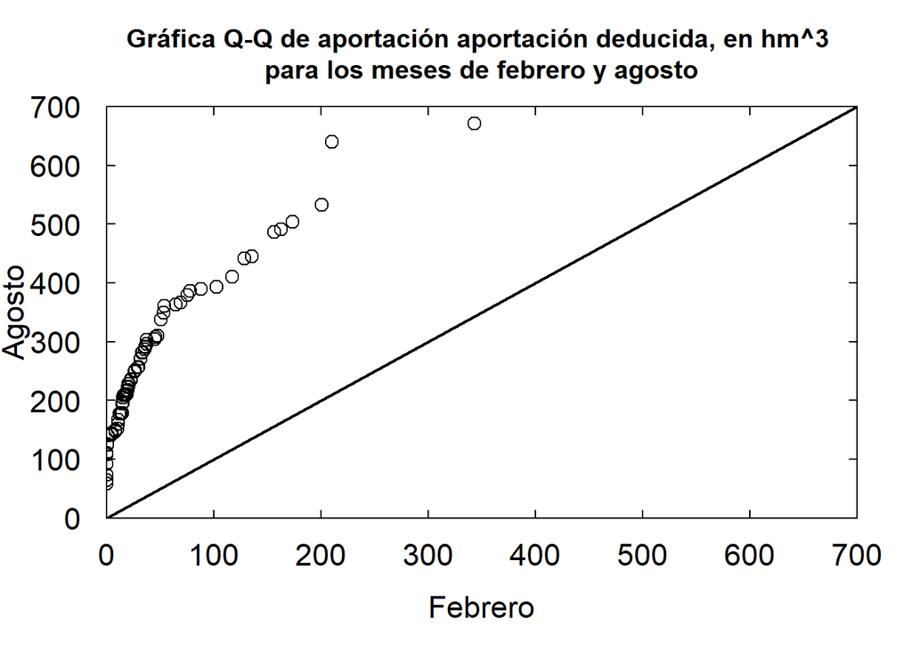

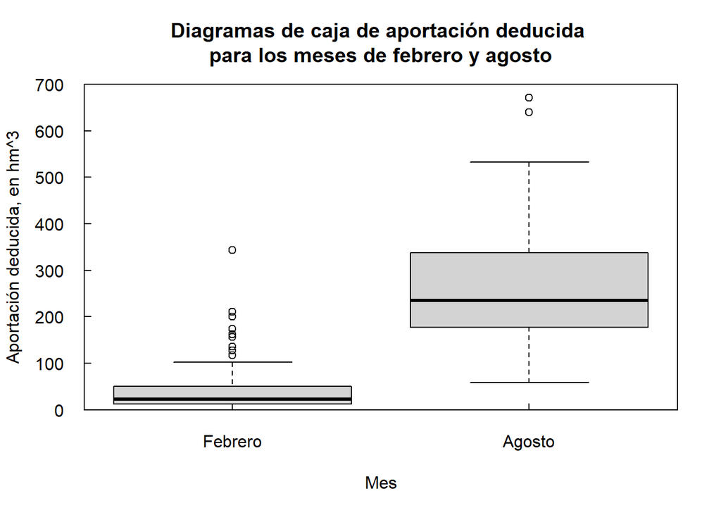

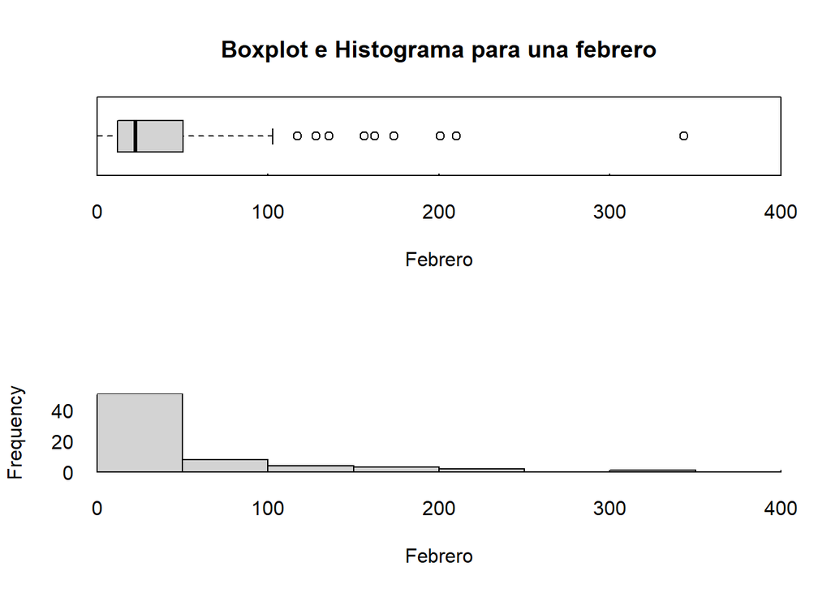

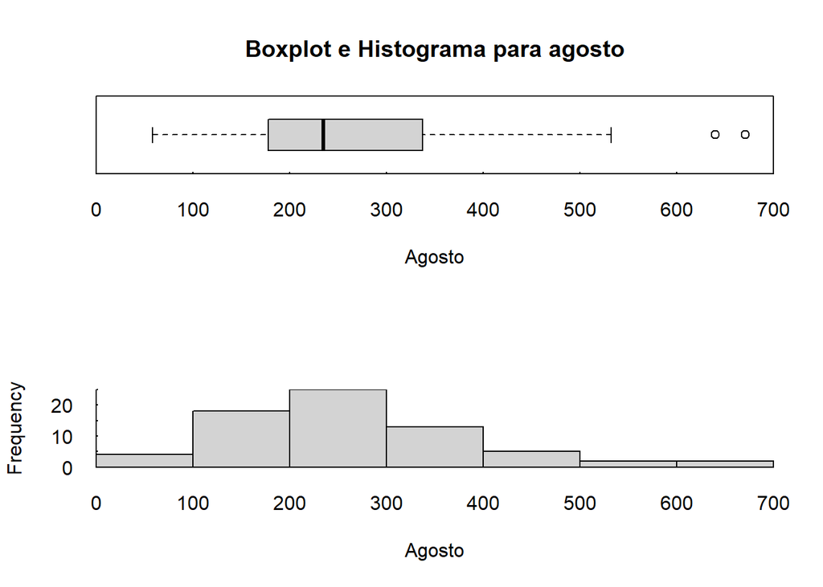

Se observa que la aportación deducida del mes de febrero se caracteriza por tener un sesgo importante hacia la derecha (positivo) debido, principalmente, a varios valores atípicos. En agosto, disminuye el sesgo y se tienen solo dos valores atípicos. Estos resultados son esperados debido a que febrero normalmente es un mes de estiaje, contrario al mes de agosto.

Tratando de normalizar el comportamiento de las dos aportaciones mensuales, se transforman con logaritmos naturales.

**Ln(Aportación deducida de febrero), $hm^{3}$**

```
##  [1]  1.60935791  3.58851754  3.57805124  3.97314821  3.62494608  3.81807050
##  [7]  3.37230739  3.12221513  2.72070315  4.35848289  4.23518274 -0.05879505
## [13]  4.85374598  3.61450337  2.08961462  1.48909911  2.99888231  5.09007844
## [19]  2.38314151  3.24659215  2.67482428  2.31557042  2.86731350  5.15758871
## [25]  0.17269201  3.44725047  1.43119602  5.30286202  3.56310362  4.76363867
## [31]  2.96410228  2.95905792        -Inf  4.63288846  4.32181209  3.98385052
## [37]  5.34798334  4.91012596  3.11772864  5.05089713  2.66706847  2.81335272
## [43]  3.51323357        -Inf        -Inf  4.16551883  3.01907764  3.80320987
## [49]  2.72355603  5.83881586  2.94065287  3.49703167  3.29149040  3.04249181
## [55]  4.47761746  2.90186106  2.07567195  2.97695712  2.59374611  3.92087967
## [61]  2.46740437  2.76280350        -Inf  3.86282856  3.39725295        -Inf
## [67]        -Inf  2.39379597 -0.29934988
```

**Ln(Aportación deducida de agosto), $hm^{3}$**

```
##  [1] 5.008737 5.184370 5.458428 6.277197 5.462578 5.601723 4.301032 5.639887
##  [9] 5.887248 4.969385 6.461590 5.409119 5.669128 4.680250 5.690259 5.964568
## [17] 5.341614 5.956663 4.971393 5.526359 4.702502 5.821910 5.547553 4.989789
## [25] 5.974450 5.544569 4.956063 5.735783 6.188026 5.938724 5.674765 5.717466
## [33] 6.221670 5.893751 5.729581 6.197817 5.322042 5.372766 5.268226 5.352578
## [41] 5.903182 5.340332 5.431450 5.187000 5.020305 5.077868 5.352988 5.403317
## [49] 4.828103 5.657693 5.644796 5.856371 6.016583 5.120591 5.431652 5.273878
## [57] 5.384899 4.945610 6.098683 5.516616 6.091053 5.713248 5.179571 4.521622
## [65] 4.066650 5.342227 6.508309 4.162813 4.822210
```

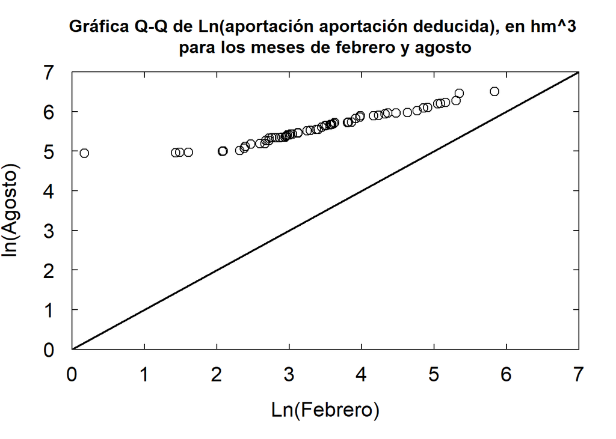

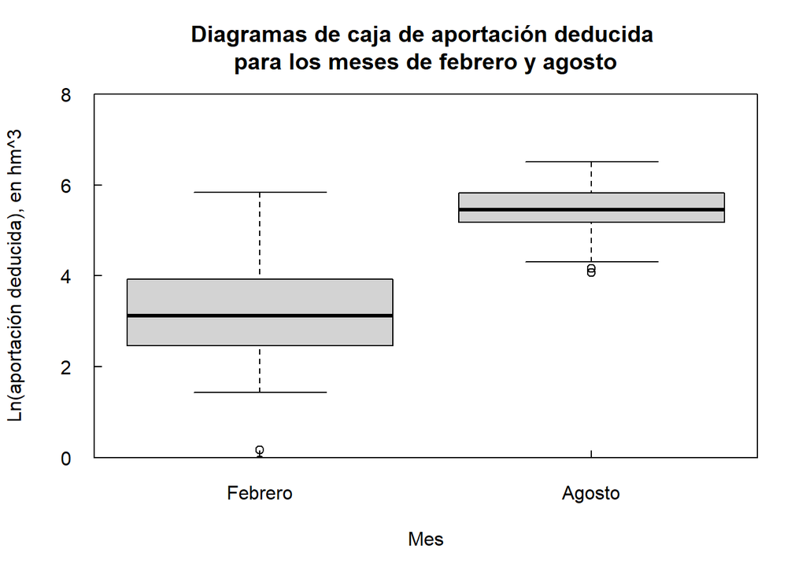

[figure not shown]

El gráfico Q-Q muestra claramente que las dos distribuciones son bastante diferentes, basándose en el hecho de que los puntos caen muy lejos de la línea 1:1. Los diagramas de caja uno al lado del otro proporcionan una forma muy clara de ver las diferencias a simple vista. La diferencia en las medianas y la diferencia en la variabilidad son muy claras. Sin embargo, debido a que los datos están tan sesgados, un conjunto de diagramas de caja uno al lado del otro de las concentraciones logarítmicas puede ser la forma más clara de ver las diferencias entre las dos distribuciones. La diferencia en las medianas es muy clara y muestra que agosto tiene una mediana más alta y los cuartiles también muestran lo mismo. Tenga en cuenta que este es un diagrama de caja de los logaritmos y no un diagrama de caja de los datos originales con su escala con una transformación logarítmica. Se debe tener cuidado de presentar una escala en las unidades originales, así como la escala logarítmica en la que se presentan los diagramas de caja.

## Análisis descriptivo de datos

Generalmente, en estadística descriptiva se considera un conjunto de datos provenientes de mediciones que se utilizan para conocer una población. En el Ejemplo 1 anterior, se analizaron gráficamente dos conjuntos de datos resultantes de mediciones mensuales de la aportación deducida. Ambos conjuntos de datos son una muestra de una población muy grande (infinita) y solo se tienen acceso a una parte de esa población y se utilizan para tratar de caracterizar la población general. Para seleccionar el método estadístico correcto, se necesita conocer sobre las características de los datos.

### Ejemplo 2.

Con base en las muestras de aportación deducida mensuales de febrero y agosto, *describir qué tan variable podría ser la población de la aportación deducida mensual*.

Explicar las razones para preferir usar estimadores puntuales clásicos (media, desviación estándar, sesgo, …) o robustos (mediana, desviacion absoluta mediana, sesgo de cuartil,…)

**Febrero:**

Calcule los valores de los términos que se enumeran a continuación para el mes de febrero. Luego compare estas estimaciones de ubicación. ¿Por qué difieren?

A. Media  
B. Media recortada (con un recorte del 10 por ciento y del 20 por ciento)  
C. Media geométrica  
D. Mediana

**Aportación deducida,** $hm^{3}$:

```
##  [1]   4.9996  36.1804  35.8037  53.1516  37.5227  45.5163  29.1457  22.6966
##  [9]  15.1910  78.1385  69.0743   0.9429 128.2198  37.1329   8.0818   4.4331
## [17]  20.0631 162.4026  10.8389  25.7026  14.5098  10.1307  17.5897 173.7450
## [25]   1.1885  31.4139   4.1837 200.9110  35.2725 117.1715  19.3773  19.2798
## [33]   0.0000 102.8106  75.3250  53.7235 210.1840 135.6565  22.5950 156.1625
## [41]  14.3977  16.6657  33.5566   0.0000   0.0000  64.4261  20.4724  44.8449
## [49]  15.2344 343.3725  18.9282  33.0173  26.8829  20.9574  88.0247  18.2080
## [57]   7.9699  19.6280  13.3798  50.4448  11.7918  15.8442   0.0000  47.5998
## [65]  29.8819   0.0000   0.0000  10.9550   0.7413
```

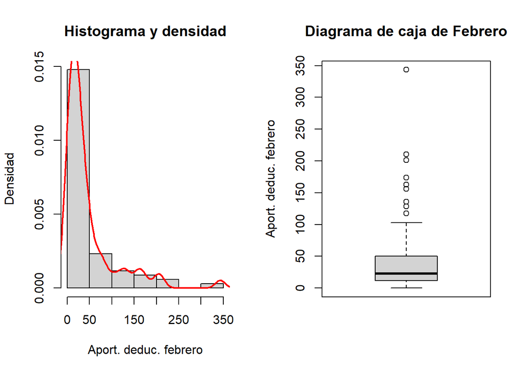

Media = (46.3)

Media recortada (0.1) = (34.1564263)

Media recortada (0.2) = (27.8397837)

**ln(aportación deducida),** $hm^{3}$:

```
##  [1]  1.60935791  3.58851754  3.57805124  3.97314821  3.62494608  3.81807050
##  [7]  3.37230739  3.12221513  2.72070315  4.35848289  4.23518274 -0.05879505
## [13]  4.85374598  3.61450337  2.08961462  1.48909911  2.99888231  5.09007844
## [19]  2.38314151  3.24659215  2.67482428  2.31557042  2.86731350  5.15758871
## [25]  0.17269201  3.44725047  1.43119602  5.30286202  3.56310362  4.76363867
## [31]  2.96410228  2.95905792        -Inf  4.63288846  4.32181209  3.98385052
## [37]  5.34798334  4.91012596  3.11772864  5.05089713  2.66706847  2.81335272
## [43]  3.51323357        -Inf        -Inf  4.16551883  3.01907764  3.80320987
## [49]  2.72355603  5.83881586  2.94065287  3.49703167  3.29149040  3.04249181
## [55]  4.47761746  2.90186106  2.07567195  2.97695712  2.59374611  3.92087967
## [61]  2.46740437  2.76280350        -Inf  3.86282856  3.39725295        -Inf
## [67]        -Inf  2.39379597 -0.29934988
```

Media geométrica = (0)

Mediana = (22.595)

La muestra está muy sesgada positivamente (sesgada hacia la derecha). La media está fuertemente influenciada por las observaciones más altas. Las dos versiones de la media recortada están algo menos influenciadas por los valores muy altos, pero aun así, tienen un fuerte efecto sobre los valores de la media recortada.

La media geométrica proporciona una medida de tendencia central que es mucho más baja porque se utilizó la transformación logarítmica en los datos. La mediana también es mucho más baja que la media o la media recortada, no está influenciada por la magnitud de los valores muy altos en el conjunto de datos.

Para los datos de aportación deducida para el mes de febrero, calcule los valores de los términos que se enumeran a continuación. Luego, analice las diferencias en los valores de A a C.

A. Desviación estándar

B. Rango intercuartil

C. Desviación absoluta mediana

D. Sesgo y sesgo cuartil

Desviación estándar = (61.5248902)

Rango intercuartil = (40.4248)

Desviación absoluta mediana = (14.6251)

Sesgo = (2.5619285)

Sesgo de cuartil = (0.4448161)

Debido a que el conjunto de datos es asimétrico, la desviación absoluta mediana es pequeña y la desviación estándar y el Rango intercuartil son mucho mayores.

**Agosto:**

Calcule los valores de los términos que se enumeran a continuación para el mes de agosto. Luego compare estas estimaciones de ubicación. ¿Por qué difieren?

A. Media  
B. Media recortada (con un recorte del 10 por ciento y del 20 por ciento)  
C. Media geométrica  
D. Mediana

**Aportación deducida,** $hm^{3}$:

```
##  [1] 149.7155 178.4610 234.7281 532.2945 235.7044 270.8927  73.7759 281.4309
##  [9] 360.4122 143.9383 640.0781 223.4347 289.7818 107.7970 295.9703 389.3848
## [17] 208.8496 386.3189 144.2277 251.2275 110.2226 337.6163 256.6089 146.9054
## [25] 393.2518 255.8442 142.0335 309.7554 486.8841 379.4506 291.4198 304.1334
## [33] 503.5435 362.7636 307.8402 491.6744 204.8016 215.4579 194.0714 211.1520
## [41] 366.2010 208.5819 228.4802 178.9309 151.4575 160.4317 211.2386 222.1420
## [49] 124.9736 286.4869 282.8159 349.4536 410.1745 167.4343 228.5264 195.1714
## [57] 218.0880 140.5565 445.2711 248.7917 441.8863 302.8532 177.6066  91.9847
## [65]  58.3611 208.9776 670.6911  64.2520 124.2394
```

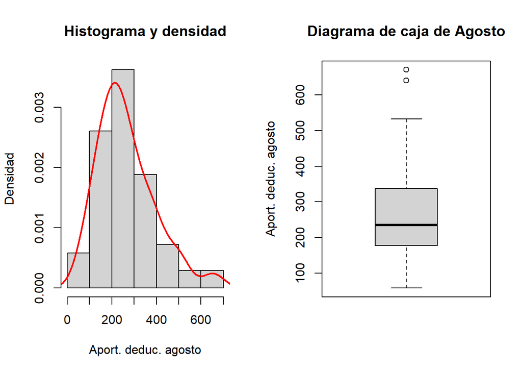

Media = (265)

Media recortada (0.1) = (253.3044772)

Media recortada (0.2) = (247.1102977)

**ln(aportación deducida),** $hm^{3}$:

```
##  [1] 5.008737 5.184370 5.458428 6.277197 5.462578 5.601723 4.301032 5.639887
##  [9] 5.887248 4.969385 6.461590 5.409119 5.669128 4.680250 5.690259 5.964568
## [17] 5.341614 5.956663 4.971393 5.526359 4.702502 5.821910 5.547553 4.989789
## [25] 5.974450 5.544569 4.956063 5.735783 6.188026 5.938724 5.674765 5.717466
## [33] 6.221670 5.893751 5.729581 6.197817 5.322042 5.372766 5.268226 5.352578
## [41] 5.903182 5.340332 5.431450 5.187000 5.020305 5.077868 5.352988 5.403317
## [49] 4.828103 5.657693 5.644796 5.856371 6.016583 5.120591 5.431652 5.273878
## [57] 5.384899 4.945610 6.098683 5.516616 6.091053 5.713248 5.179571 4.521622
## [65] 4.066650 5.342227 6.508309 4.162813 4.822210
```

Media geométrica = (234.3190727)

Mediana = (234.7281)

Ahora, para los datos de aportación decucida para el mes de agosto, calcule los valores de los términos que se enumeran a continuación. Luego, analice las diferencias en los valores de A a C.

A. Desviación estándar

B. Rango intercuartil

C. Desviación absoluta mediana

D. Sesgo y sesgo cuartil

Desviación estándar = (130.2096688)

Rango intercuartil = (171.0145)

Desviación absoluta mediana = (74.2964)

Sesgo = (0.9673004)

Sesgo de cuartil = (0.2724868)

Debido a que el conjunto de datos es asimétrico, la desviación absoluta mediana es pequeña y la desviación estándar y el rango intercuartil son mucho mayores.

# ESTADÍSTICA INFERENCIAL

## Dos muestras independientes

Los ejemplos siguientes comparan dos grupos independientes de datos para determinar si un grupo tiende a contener valores mayores que el otro. Los datos son independientes cuando no están emparejados, es decir, cuando no hay emparejamientos de datos entre la observación 1 del grupo 1 y la observación 1 del grupo 2, y así sucesivamente. Los datos también deben ser independientes en el sentido de que los dos grupos representan condiciones diferentes (ni las observaciones ni la población que representan deben estar en ambos grupos).

### Ejemplo 3

Los caudales anuales del río Green en Munfordville, Kentucky, se regularon a partir de 1969 por un embalse.

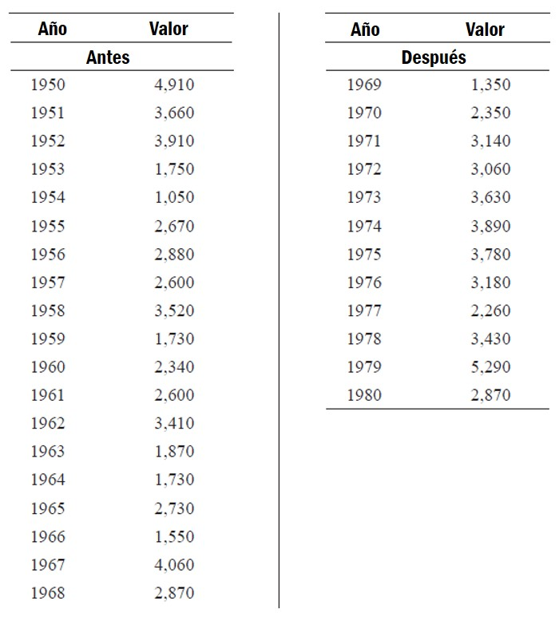

Ejemplo 3

A. Construya un gráfico Q-Q que compare las distribuciones de los dos grupos.

B. Pruebe si los caudales después de que el embalse comenzó a funcionar difieren de los caudales anteriores. (Cualquier diferencia puede atribuirse al efecto del embalse, a las diferencias climáticas entre los períodos y probablemente a ambos. Este simple ejercicio no le permitirá separar las dos posibles causas).

**A**

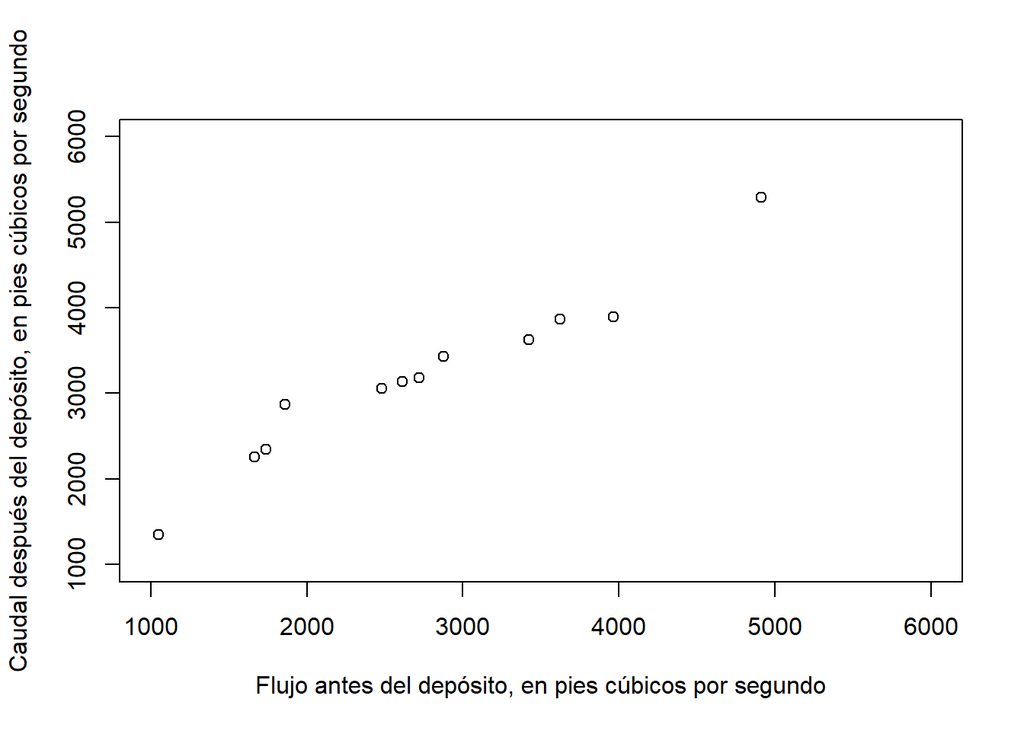

**B**

1. Seleccionar la prueba apropiada
1. Paramétrica o no paramétrica

Normalidad antes:

```
##
##  Shapiro-Wilk normality test
##
## data:  qGreenRiverBef$anflow
## W = 0.96983, p-value = 0.773
```

```
##
##  Anderson-Darling normality test
##
## data:  qGreenRiverBef$anflow
## A = 0.26887, p-value = 0.6407
```

```
##
##  Lilliefors (Kolmogorov-Smirnov) normality test
##
## data:  qGreenRiverBef$anflow
## D = 0.12399, p-value = 0.6186
```

Normalidad después:

[output not shown]

```
##
##  Anderson-Darling normality test
##
## data:  qGreenRiverAft$anflow
## A = 0.27563, p-value = 0.5908
```

```
##
##  Lilliefors (Kolmogorov-Smirnov) normality test
##
## data:  qGreenRiverAft$anflow
## D = 0.15656, p-value = 0.5745
```

Se cumple con normalidad.

Con respecto a la heterocedasticidad:

```
##
##  F test to compare two variances
##
## data:  qGreenRiverBef$anflow and qGreenRiverAft$anflow
## F = 1.0295, num df = 18, denom df = 11, p-value = 0.993
## alternative hypothesis: true ratio of variances is not equal to 1
## 95 percent confidence interval:
##  0.3156819 2.8967720
## sample estimates:
## ratio of variances
##           1.029513
```

Como *p* > 0.05, se acepta la igualdad de varianzas.

Por lo tanto, debe ser una prueba paramétrica.

b: Objetivo: *Diferencia entre las medias de ambas muestras independientes*.

2. Establecer las hipótesis nula y alternativa.

3. Decidir una tasa de error aceptable.

α = 0.05

4. Seleccionar la prueba estadística de los datos.

Entonces, se aplica la prueba *t* para dos muestras independientes y con varianzas iguales.

```
##
##  Two Sample t-test
##
## data:  qGreenRiverBef$anflow and qGreenRiverAft$anflow
## t = -1.2673, df = 29, p-value = 0.1076
## alternative hypothesis: true difference in means is less than 0
## 95 percent confidence interval:
##      -Inf 158.3966
## sample estimates:
## mean of x mean of y
##  2728.421  3193.333
```

Como *p* > 0.05, no existe una diferencia significativa entre los caudales antes y después de la construcción del embalse con un nivel de confianza del 0.95 %.

**C**. Los rendimientos unitarios de los pozos, en galones por minuto por pie de material acuífero, se contrastaron para pozos dentro de valles que contenían roca fracturada frente a valles sin fracturas (Wright, 1985). Realice la prueba α = 0.05 adecuada para discernir si la fracturación está asociada con un mayor rendimiento unitario medio del pozo.

| Rendimientos de pozos en roca fracturada | Rendimientos de pozos en roca no fracturada |
| --- | --- |
| 0.95 | 1.02 |
| 0.72 | 0.49 |
| 0.51 | 0.454 |
| 0.44 | 0.10 |
| 0.40 | 0.077 |
| 0.30 | 0.041 |
| 0.18 | 0.040 |
| 0.16 | 0.030 |
| 0.16 | 0.020 |
| 0.13 | 0.007 |
| 0.086 | 0.003 |
| 0.031 | 0.001 |
| 0.020 |  |

1. Seleccionar la prueba apropiada.
1. Prueba paramétrica o no paramétrica

Normalidad con fracturas:

```
##
##  Shapiro-Wilk normality test
##
## data:  withfrac
## W = 0.88531, p-value = 0.08418
```

```
##
##  Anderson-Darling normality test
##
## data:  withfrac
## A = 0.5767, p-value = 0.108
```

```
##
##  Lilliefors (Kolmogorov-Smirnov) normality test
##
## data:  withfrac
## D = 0.22209, p-value = 0.07904
```

Normalidad sin fracturas:

```
##
##  Shapiro-Wilk normality test
##
## data:  withoutfrac
## W = 0.66039, p-value = 0.0003593
```

```
##
##  Anderson-Darling normality test
##
## data:  withoutfrac
## A = 1.7778, p-value = 6.909e-05
```

```
##
##  Lilliefors (Kolmogorov-Smirnov) normality test
##
## data:  withoutfrac
## D = 0.3637, p-value = 9.882e-05
```

Heterocedasticidad:

```
##
##  F test to compare two variances
##
## data:  withfrac and withoutfrac
## F = 0.81082, num df = 12, denom df = 11, p-value = 0.7215
## alternative hypothesis: true ratio of variances is not equal to 1
## 95 percent confidence interval:
##  0.2364181 2.6931325
## sample estimates:
## ratio of variances
##          0.8108227
```

Como *p* > 0.05, se acepta la igualdad de varianzas.

b: Objetivo: *Diferencia entre las medias de ambas muestras independientes*.

2. Establecer las hipótesis nula y alternativa.

3. Decidir una tasa de error aceptable.

α = 0.05

4. Seleccionar la prueba estadística de los datos.

Entonces, se aplica la prueba *t* para dos muestras independientes y con varianzas iguales.

```
##
##  Two Sample t-test
##
## data:  withfrac and withoutfrac
## t = 1.0459, df = 23, p-value = 0.8468
## alternative hypothesis: true difference in means is less than 0
## 95 percent confidence interval:
##      -Inf 0.327554
## sample estimates:
## mean of x mean of y
## 0.3143846 0.1902500
```

Como *p* > 0.05, no existe una diferencia significativa entre los rendimientos unitarios de las rocas fracturadas y no fracturadas con un nivel de confianza del 0.95 %.

### Ejemplo 4

El acuífero superficial está contaminado por lixiviado de molibdeno proveniente de los relaves de la mina. Se inició un esfuerzo de remediación para reducir las concentraciones de molibdeno en las aguas que salen del sitio. A continuación se enumeran las concentraciones posteriores a la remediación (en μg/L) de 13 pozos ubicados en la línea de abajo del proceso de remediación. También se muestran las concentraciones en 3 pozos ubicados en la línea de arriba del proceso de remediación y que no se vieron afectados por él. Pruebe si los pozos ubicados en la línea de abajo del proceso de remediación tienen un contenido significativamente menor de molibdeno que los pozos ubicados en la línea de arriba. Pruebe también si la concentración media ha cambiado con la remediación.

| Gradiente aguas abajo | Gradiente aguas arriba |
| --- | --- |
| 0.850 | 6.900 |
| 0.390 | 3.200 |
| 0.320 | 1.700 |
| 0.300 |  |
| 0.300 |  |
| 0.205 |  |
| 0.200 |  |
| 0.200 |  |
| 0.140 |  |
| 0.140 |  |
| 0.090 |  |
| 0.046 |  |
| 0.035 |  |

Mediana contaminación gradiente aguas arriba = (3.2)  
Mediana contaminación gradiente aguas abajo = (0.2)

1. Seleccionar la prueba apropiada
1. Paramétrica o no paramétrica

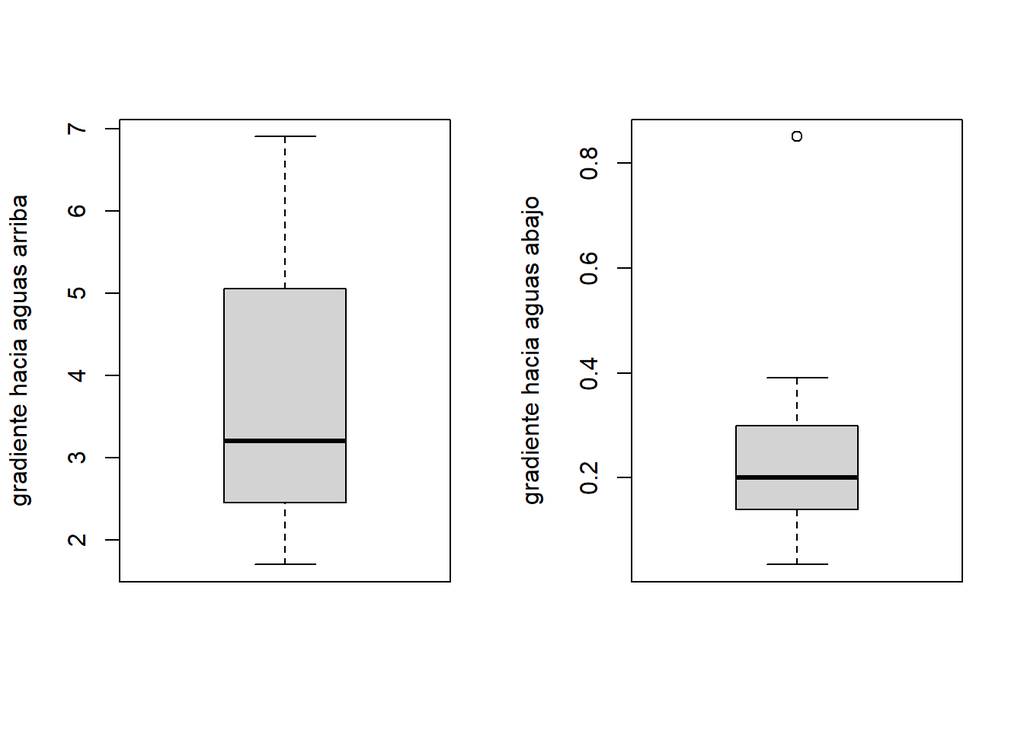

Normalidad gradiente hacia aguas arriba:

```
##
##  Shapiro-Wilk normality test
##
## data:  upgrad
## W = 0.94369, p-value = 0.5425
```

```
##
##  Shapiro-Wilk normality test
##
## data:  downgrad
## W = 0.79532, p-value = 0.006001
```

```
##
##  Anderson-Darling normality test
##
## data:  downgrad
## A = 0.87943, p-value = 0.01713
```

```
##
##  Lilliefors (Kolmogorov-Smirnov) normality test
##
## data:  downgrad
## D = 0.2115, p-value = 0.1152
```

Heterocedasticidad:

```
##
##  F test to compare two variances
##
## data:  upgrad and downgrad
## F = 160.95, num df = 2, denom df = 12, p-value = 4.309e-09
## alternative hypothesis: true ratio of variances is not equal to 1
## 95 percent confidence interval:
##    31.58453 6343.80409
## sample estimates:
## ratio of variances
##           160.9506
```

Hay desigualdad de varianzas.

Por lo tanto, la prueba debe ser *no paramátrica*.

b: Objetivo: *Diferencia entre las medianas de ambas muestras independientes*.

2. Establecer las hipótesis nula y alternativa.

$H_{0}$: Prob(contaminación downgrad > contaminación upgrad)=0.5 o probabilidad de que un valor downgrad sea mayor que cualquier valor upgrad dado es 0.5.

3. Decidir una tasa de error aceptable.

α = 0.05

4. Seleccionar la prueba estadística de los datos.

Entonces, se aplica la prueba no paramétrica de suma de rangos de Wilcoxon para dos muestras independientes.

Las medianas de las contaminaciones para el gradiente aguas arriba y el gradiente aguas abajo son 3.2 y 0.2 μg/L, respectivamente. La prueba de suma de rangos determinará estadísticamente si la concentración del gradiente aguas abajo a disminuido significativamente, con α = 0.05, después de la remediación.

```
##
##  Wilcoxon rank sum test with continuity correction
##
## data:  downgrad and upgrad
## W = 0, p-value = 0.005206
## alternative hypothesis: true location shift is less than 0
## 95 percent confidence interval:
##       -Inf -1.499996
## sample estimates:
## difference in location
##              -2.999963
```

debido a que α es menor que 0.05, se rechaza $H_{0}$ y se acepta $H_{1}$. Es decir, se encuentra una diferencia en las dos muestras. Según la prueba de suma de rangos, hay una disminución significativa en las concentraciones después de la remediación.